# Análisis de expresión génica y funcional de la Electroacupuntura en *Rattus Norvegicus*

# 4 Resultados

## 4.1 Análisis de expresión diferencial

### 4.1.1 PCA

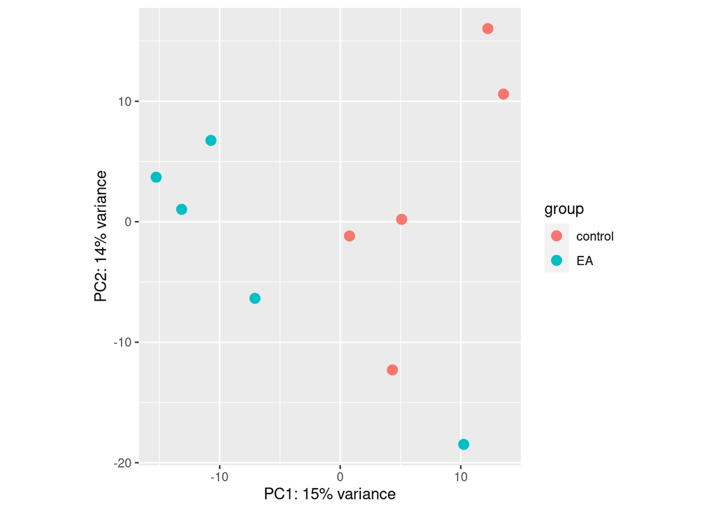

```r
plotPCA(Rn_all_normalized, intgroup=c("dex"))
```

### 4.1.2 Expresión diferencial

```r
# Numero de genes expresados
length(Rn_all_de_gene_names_UP)
```

```
## [1] 156
```

```r
length(Rn_all_de_gene_names_DOWN)
```

```
## [1] 184
```

### 4.1.3 Volcano plot

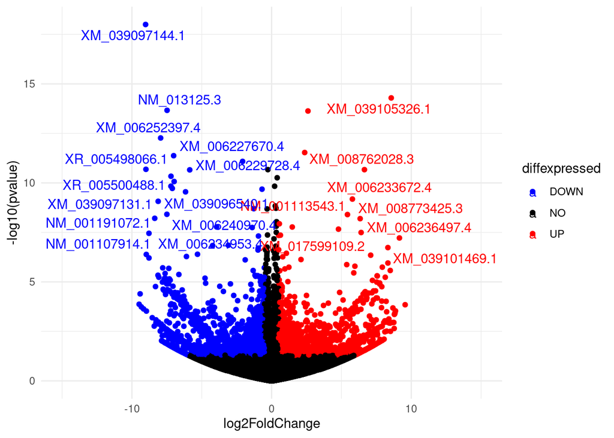

```r
# Volvemos los resultados en data frame
Rn_de <- as.data.frame(Rn_res_all)
# add a column of NAs
Rn_de$diffexpressed <- "NO"
# if log2Foldchange > 0.6 and pvalue < 0.05, set as "UP"
Rn_de$diffexpressed[Rn_de$log2FoldChange > 0.5 & Rn_de$pvalue < 0.05] <- "UP"
# if log2Foldchange < -0.6 and pvalue < 0.05, set as "DOWN"
Rn_de$diffexpressed[Rn_de$log2FoldChange < -0.5 & Rn_de$pvalue < 0.05] <- "DOWN"
# Create a new column "names" to de, that will contain the name of a subset if genes differentially expressed (NA in case they are not)
Rn_de$names <- NA
# filter for a subset of interesting genes
filter <- which(Rn_de$diffexpressed != "NO" & Rn_de$padj < 0.05 & (Rn_de$log2FoldChange >= 5  | Rn_de$log2FoldChange <= -5))
Rn_de$names[filter] <- rownames(Rn_de)[filter]
# grafica
#png(file = "volcano05-res.png",
#    width = 800, height = 800) # guardar el plot en formato png
ggplot(data=Rn_de, aes(x=log2FoldChange, y=-log10(pvalue), col=diffexpressed, label=names)) +
    geom_point() +
    scale_color_manual(values=c("blue", "black", "red")) + # cambiar colores de puntos
    theme_minimal() +
    geom_text_repel() +
    xlim(-15,15)
```

Lo que podemos observar es que existen varios genes sobre y subregulados tras el tratamiento con acupuntura, como el gen *Wtap-201* (RefSeq mRNA ID: NM_001113543.1) y *Scn5a*.

### 4.1.4 Heatmap

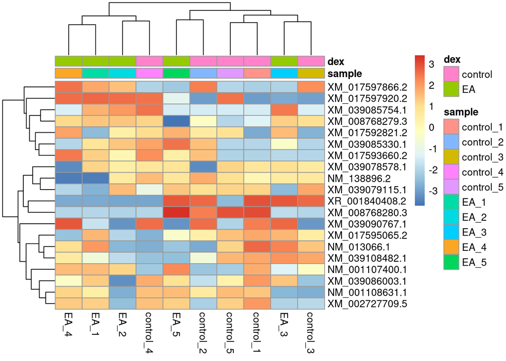

```r
library("genefilter")
library("pheatmap")
topVarGenes <- head(order(rowVars(assay(Rn_all_normalized)), decreasing = TRUE), 20)  # Seleccion de mayores genes
mat  <- assay(Rn_all_normalized)[ topVarGenes, ]  # Matriz con mayores genes
mat  <- mat - rowMeans(mat)
anno <- as.data.frame(colData(Rn_all_normalized)[, c("sample","dex")]) # Anotaciones
pheatmap(mat, annotation_col = anno) # Grafica
```

### 4.1.5 Análisis Funcional GO

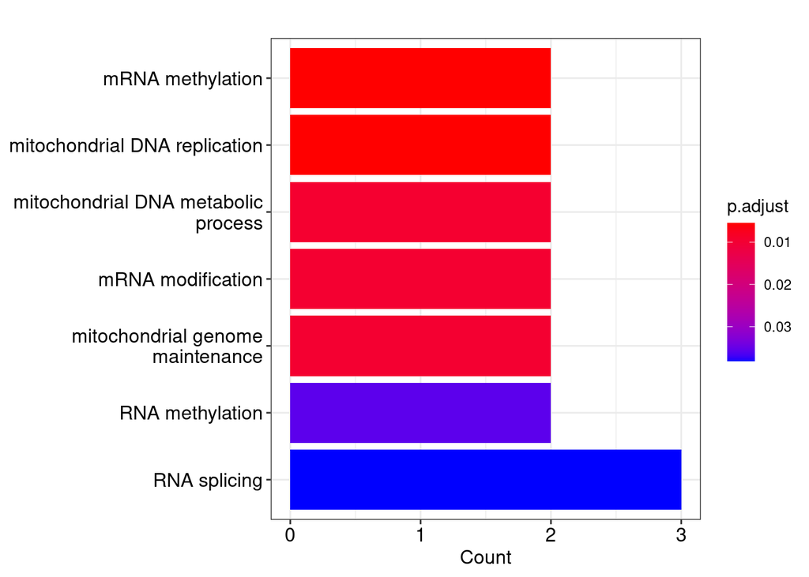

```r
# Generar la plot de los primeros 20 genes
plot(barplot(Go_results, showCategory = 7))
```

El metodo Benjamini-Hochberg disminuye el numero de errores tipo 1 (falsos positivos). Rankea todos los pvalores de menor a mayor y les asigna una posicion en el ranking, siendo el numero 1 el que tenga el pvalor mas pequeño, despues divide la posicion en el rankeo entre el numero de muestras para obtener $posicion-ranking/muestras=p-adjusted$

## 4.2 Datos

Los trabajos originales del estudio son accesibles al público y se pueden encontrar en https://www.ncbi.nlm.nih.gov/, GSE192885.

# 5 Conclusiones

En este proyecto se realizó un análisis de expresión diferencial utilizando la herramienta DESeq2. Se utilizó una función para realizar el análisis y obtener tablas de resultados con cambios de *log2 fold*, valores p y valores p ajustados. Además, se utilizó la función `getBM` del paquete `biomaRt` para obtener los nombres y las identificaciones de Ensembl de los genes. Se generaron gráficos como el *volcano plot* y el mapa de calor para visualizar los datos normalizados y la agrupación de genes que llevan una señal. También se realizó un análisis funcional de términos GO. En conclusión, se identificaron varios genes sobre y subregulados tras el tratamiento con acupuntura, lo que indica que esta técnica puede tener un impacto en la expresión génica.

# 6 Referencias

- Ma, C., Gan, L., Wang, H., Ren, L., Lin, Y., Zhao, Y., Zhang, S., Gong, P., & Lin, X. (2022). Transcriptomic Analysis of Rat Cerebral Cortex Reveals the Potential Mechanism of Electroacupuncture Opening Blood Brain Barrier. *Frontiers in Neuroscience*, *16*. https://www.frontiersin.org/articles/10.3389/fnins.2022.834683
- GEO Accession viewer. (n.d.). Retrieved May 31, 2023, from https://www.ncbi.nlm.nih.gov/geo/query/acc.cgi?acc=GSE192885
- FastQC tutorial & FAQ. (n.d.). [Msu.edu](http://msu.edu/). Retrieved May 16, 2023, from https://rtsf.natsci.msu.edu/genomics/tech-notes/fastqc-tutorial-and-faq/
- Should I remove PCR duplicates from my RNA-seq data? (n.d.). [Ucdavis.edu](http://ucdavis.edu/). Retrieved May 16, 2023, from https://dnatech.genomecenter.ucdavis.edu/faqs/should-i-remove-pcr-duplicates-from-my-rna-seq-data/
- (N.d.-a). [Biostars.org](http://biostars.org/). Retrieved May 16, 2023, from https://www.biostars.org/p/14283/
- (N.d.-b). [Ridom.de](http://ridom.de/). Retrieved May 16, 2023, from https://www.ridom.de/seqsphere/u/FASTQ_Quality_Control_(FastQC).html
- GEO Accession viewer. (n.d.-a). [Nih.gov](http://nih.gov/). Retrieved May 16, 2023, from https://www.ncbi.nlm.nih.gov/geo/query/acc.cgi?acc=GSE200762
- GEO Accession viewer. (n.d.-b). [Nih.gov](http://nih.gov/). Retrieved May 16, 2023, from https://www.ncbi.nlm.nih.gov/geo/query/acc.cgi?acc=GSM6043329
- Bell, G. (2016). Replicates and repeats. BMC Biology, 14, 28. https://doi.org/10.1186/s12915-016-0254-5
- Dai, H., & Guan, Y. (2020). Nubeam-dedup: A fast and RAM-efficient tool to de-duplicate sequencing reads without mapping. *Bioinformatics*, 36(10), 3254–3256. https://doi.org/10.1093/bioinformatics/btaa112
- Ewels/MultiQC: Aggregate results from bioinformatics analyses across many samples into a single report. (n.d.). Retrieved May 7, 2023, from https://github.com/ewels/MultiQC
- Fastq-dump. (n.d.). Bioinformatics Notebook. Retrieved May 7, 2023, from https://rnnh.github.io/bioinfo-notebook/docs/fastq-dump.html
- Iqbal, K. (2019, October 11). SH - Bash Shell Script File. https://docs.fileformat.com/programming/sh/
- Love, M. I., Anders, S., Kim, V., & Huber, W. (2016). RNA-Seq workflow: Gene-level exploratory analysis and differential expression (4:1070). *F1000Research*. https://doi.org/10.12688/f1000research.7035.2
- Making and Utilizing TxDb Objects. (n.d.). Retrieved May 16, 2023, from https://bioconductor.org/packages/devel/bioc/vignettes/GenomicFeatures/inst/doc/GenomicFeatures.html
- Risso, D., Ngai, J., Speed, T. P., & Dudoit, S. (2014). Normalization of RNA-seq data using factor analysis of control genes or samples. *Nature Biotechnology*, 32(9), 896–902. https://doi.org/10.1038/nbt.2931
- Sequence Read Archive. (2022). In Wikipedia. https://en.wikipedia.org/w/index.php?title=Sequence_Read_Archive&oldid=1064268529
- SGE File: How to open SGE file (and what it is). (n.d.). [File.Org](http://file.org/). Retrieved May 6, 2023, from https://file.org/extension/sge
- Soneson, C., Love, M. I., & Robinson, M. D. (2015). Differential analyses for RNA-seq: Transcript-level estimates improve gene-level inferences. *F1000Research*, 4, 1521. https://doi.org/10.12688/f1000research.7563.1
- Trapnell, C., Hendrickson, D. G., Sauvageau, M., Goff, L., Rinn, J. L., & Pachter, L. (2013). Differential analysis of gene regulation at transcript resolution with RNA-seq. *Nature Biotechnology*, 31(1), 46–53. https://doi.org/10.1038/nbt.2450
- Proton motive force-driven mitochondrial ATP synthesis Gene Ontology Term (GO:0042776). (n.d.). Retrieved May 16, 2023, from https://www.informatics.jax.org/vocab/gene_ontology/GO:0042776#:~:text=proton motive force-driven mitochondrial,Ontology Term (GO%3A0042776)&text=Definition%3A,force)%20that%20powers%20ATP%20synthesis.
- Stephanie. (2015, October 13). Benjamini-Hochberg Procedure. Statistics How To. https://www.statisticshowto.com/benjamini-hochberg-procedure/